# Protein Abundance Analysis

- Show All Code
- Hide All Code
- View Source

Author

André F. B. Menezes, Beatrice Tropea, Cormac Monaghan

Published

December 20, 2022

# 1 Introduction

In this report we will perform a protein abundance analysis in order to find and rank proteins showing evidence of differential protein abundance (DPA) between the control group and the various treatments (Ampicillin, Cefotaxime, Impipenem, Ciprofloxacin). We will also perform a deep investigation of the estimated $\log_2$ fold-change between Margalit, Carolan, and Walsh (2022) and the proposed approach.

The plan of this report is as followed. Section 2 provides a review of the moderated $t$-statistic proposed by Smyth (2004) and shows the obtained results. Section 3 compares the difference in terms of $\log_2$ fold-change and p-value between Margalit, Carolan, and Walsh (2022) and the moderated $t$-statistic. A further investigation is presented in Section 4, where the top 3 most differentially abundant proteins are examined.

```r
fts <- readRDS(file = "../data/fts_processed.rds")
se_fiona <- readRDS("../data/se_processed.rds")
```

# 2 Linear model

To test for the differential protein abundance, Margalit, Carolan, and Walsh (2022) used a pairwise Student-t test. It is well known that Student-t tests have several drawbacks in small sample sizes (for instance providing high false discovery rates). In order to overcome this limitation we will use the moderated $t$-statistic introduced by Smyth (2004). This method was proposed in the context of microarray experiments, although it can be easily adapted for label-free MS/MS data, since the response variable, $\log_2$ normalized intensity, can usually be well approximated by a Normal distribution.

## 2.1 The moderated $t$-statistic

The moderated $t$-statistic is derived from a hierarchical linear model, defined by the existence of second order moments as follows

$$\mathbb{E}(\mathbf{y}_{g}) = \mathbf{X}\,\boldsymbol{\alpha}_g$$
and
$$\mathrm{Var}(\mathbf{y}_{g}) = \mathbf{W}_g\,\sigma^2_g$$

Usually the design matrix contains dummies variables indicating which group the sample belongs. After the estimate $\boldsymbol{\alpha}_g$ the biological interest is to test hypotheses about certain contrasts of $\boldsymbol{\alpha}_g$, without loss of generality we can define the null hypothesis as follows
$$\mathcal{H}_0: \boldsymbol{\beta}_g = \mathbf{0}$$
where $\boldsymbol{\beta} = \mathbf{c}^\top \boldsymbol{\alpha}_g$.

For example, the design matrix in this study is given by

```r
# Creating the design matrix
g <- factor(colData(fts)$group)
g <- relevel(g, ref = "Control")
design_matrix <- model.matrix(~ g)
colnames(design_matrix) <- gsub("g", "", colnames(design_matrix))
design_matrix
```

```
   (Intercept) Ampicillin Cefotaxime Ciprofloxacin Impipenem
1            1          1          0             0         0
2            1          1          0             0         0
3            1          1          0             0         0
4            1          0          1             0         0
5            1          0          1             0         0
6            1          0          1             0         0
7            1          0          0             1         0
8            1          0          0             1         0
9            1          0          0             1         0
10           1          0          0             0         0
11           1          0          0             0         0
12           1          0          0             0         0
13           1          0          0             0         1
14           1          0          0             0         1
15           1          0          0             0         1
attr(,"assign")
[1] 0 1 1 1 1
attr(,"contrasts")
attr(,"contrasts")$g
[1] "contr.treatment"
```

Note that the Control group is set as the reference level. Therefore, a contrast matrix to test all pairwise comparison against the Control control is given by

```r
mat_contrast <- matrix(c(-1, 1, 0, 0, 0,
                         -1, 0, 1, 0, 0,
                         -1, 0, 0, 1, 0,
                         -1, 0, 0, 0, 1),
                       nrow = 4, byrow = TRUE)
colnames(mat_contrast) <- c("Control", "Ampicillin", "Cefotaxime", "Impipenem",
                            "Ciprofloxacin")
rownames(mat_contrast) <- paste0("Contrast ", 1L:4L)
mat_contrast
```

```
           Control Ampicillin Cefotaxime Impipenem Ciprofloxacin
Contrast 1      -1          1          0         0             0
Contrast 2      -1          0          1         0             0
Contrast 3      -1          0          0         1             0
Contrast 4      -1          0          0         0             1
```

For each protein $g = 1,\ldots, k$ the linear model is fitted to get the parameter estimators $\widehat{\mathbf{\alpha}}_g$, $\widehat{s}_g$ of $\sigma_g^2$, and the covariance matrices

$$\mathrm{Var}(\boldsymbol{\alpha}_{g}) = \mathbf{V}_g\,s_g^2,$$
and
$$\mathrm{Var}(\boldsymbol{\beta}_{g}) = \mathbf{c}\,\mathbf{V}_g\,\mathbf{c}^\top\,s_g^2$$

An important remark is that the response variable is not necessarily normally distributed and the parameters can be estimated with other methods rather than ordinary least squares. Let $\beta_{jg}$ a specific $j$ contrast of protein $g$, the distribution assumptions made by Smyth (2004) are in the estimators, i.e.,

$$\begin{align}
\widehat{\beta}_{gj} \mid \beta_{gj}, \sigma^2_g &\sim N[\beta_{gj}, v_{gj}\,\sigma_g^2] \\
s_g^2 \mid \sigma_g^2 &\sim \dfrac{\sigma_g^2}{d_g}\,\chi^2_{d_g}
\end{align}$$
where $v_{gj}$ is the $j$th diagonal element of $\mathbf{c}\,\mathbf{V}_g\,\mathbf{c}^\top$, and $d_g$ is the residual degree of freedom for the linear model of protein $g$.

Another interesting aspect developed by Smyth (2004) is the possibility of borrowing information across proteins through use of prior information for the parameters $\beta_{gj}$ and $\sigma_g^2$.

To describe how the variances are expected to vary across the proteins Smyth (2004) assumes the following prior distribution for $\sigma_g^2$

$$\dfrac{1}{\sigma_g^2} \sim \dfrac{1}{d_0\,s_0^2}\chi^2_{d_0}$$
with a prior sample variance $s_0^2$ and $d_0$ degrees of freedom.

An important note is that Smyth (2004) specified a conjugate prior for the sample variance $s^2_g$ given $\sigma^2_g$, which can be summarized as:

$$\begin{align}
(s^2_g \mid \sigma_g^2) &\sim \textrm{Gamma}\left[\dfrac{d_g}{2} , \dfrac{d_g}{2\,\sigma_g^2}\right] \\
\dfrac{1}{\sigma^2_g} &\sim \textrm{Gamma}\left[\dfrac{d_0}{2} , \dfrac{d_0\,s_0^2}{2}\right]
\end{align}$$
where $X \sim \textrm{Gamma}(a, b)$ means a gamma distribution with shape parameter $a$, rate parameter $b$, and expected values $\mathbb{E}(X) = \dfrac{a}{b}$.

Note that the $\mathbb{E}\left[\dfrac{1}{\sigma^2_g}\right] = \dfrac{1}{s_0^2}$. Also, note that since the shape parameter is known, the conjugate prior leads to the following posterior distribution

$$\left(\dfrac{1}{\sigma_g^2} \mid s^2_g \right) \sim \textrm{Gamma}\left[\dfrac{d_0 + d_g}{2} , \dfrac{d_0\,s_0^2 + d_g\,s_g^2}{2}\right]$$
which has the following posterior mean:
$$\mathbb{E}\left(\dfrac{1}{\sigma_g^2} \mid s^2_g \right) = \dfrac{1}{\widetilde{s}^2_g}= \dfrac{d_0 + d_g}{d_0\,s_0^2 + d_g\,s_g^2}$$
Hence, Smyth (2004) defined the moderated $t$-statistic for protein $g$ by

$$\widetilde{t}_{gj} = \dfrac{\widehat{\beta}_{gj}}{\widetilde{s}_g\,\sqrt{v_{gi}}}$$
where the posterior variance has replaced the usual sample variance of ordinary $t$-statistic.

Smyth (2004) showed that under the null hypothesis the asymptotic distribution of $\widetilde{t}_{gj}$ is t-Student with $d_g + d_0$ degrees of freedom. The additional degrees of freedom in $\widetilde{t}_{gj}$ reflects the extra information borrow between the proteins.

From this point, the model assume that $d_0$ and $s_0^2$ are known. Smyth (2004) proposes an empirical Bayes approach to estimate these parameters from the data. Particularly, $d_0$ and $s_0^2$ are estimated using the method of moments and the distribution of $s_g^2$, which is shown to follows a a scaled $F$-distribution.

The moderated t-statistic is available in the `limma` package throughout the `eBayes` function.

```r
fit <- limma::lmFit(object = assay(fts[["proteins"]], "log2_normalized"),
                    design = design_matrix)
fit <- limma::eBayes(fit)
ampicillin <- limma::topTable(fit, coef = "Ampicillin", number = Inf,
                              sort.by = "none", confint = FALSE)
cefotaxime <- limma::topTable(fit, coef = "Cefotaxime", number = Inf,
                              sort.by = "none", confint = FALSE)
impipenem <- limma::topTable(fit, coef = "Impipenem", number = Inf,
                             sort.by = "none", confint = FALSE)
ciprofloxacin <- limma::topTable(fit, coef = "Ciprofloxacin", number = Inf,
                                 sort.by = "none", confint = FALSE)

# Appending
data_de_limma <- dplyr::bind_rows(
    dplyr::mutate(ampicillin, group = "Ampicillin",
                  protein = rownames(ampicillin)),
    dplyr::mutate(cefotaxime, group = "Cefotaxime",
                  protein = rownames(cefotaxime)),
    dplyr::mutate(impipenem, group = "Impipenem",
                  protein = rownames(impipenem)),
    dplyr::mutate(ciprofloxacin, group = "Ciprofloxacin",
                  protein = rownames(ciprofloxacin))) |>
  dplyr::as_tibble() |>
  dplyr::mutate(method = "limma") |>
  dplyr::select(method, protein, group, logFC, P.Value, adj.P.Val) |>
  dplyr::rename(log_fc = logFC, p_value = P.Value, fdr = adj.P.Val)

# Fiona's Student t-test --------------------------------------------------
expr_mat <- assay(se_fiona)
list_student_t <- lapply(seq_len(nrow(expr_mat)), function(i) {
  x_contrl <- expr_mat[i, colData(se_fiona)$group == "Control"]
  x_ampici <- expr_mat[i, colData(se_fiona)$group == "Ampicillin"]
  x_cefota <- expr_mat[i, colData(se_fiona)$group == "Cefotaxime"]
  x_impipe <- expr_mat[i, colData(se_fiona)$group == "Impipenem"]
  x_ciprof <- expr_mat[i, colData(se_fiona)$group == "Ciprofloxacin"]
  tibble::tibble(
    protein = rowData(se_fiona)$protein__id[i],
    group = c("Ampicillin", "Cefotaxime", "Impipenem", "Ciprofloxacin"),
    log_fc = c(mean(x_ampici - x_contrl), mean(x_cefota - x_contrl),
               mean(x_impipe - x_contrl), mean(x_ciprof - x_contrl)),
    p_value = c(t.test(x_contrl, x_ampici, var.equal = TRUE)$p.value,
                t.test(x_contrl, x_cefota, var.equal = TRUE)$p.value,
                t.test(x_contrl, x_impipe, var.equal = TRUE)$p.value,
                t.test(x_contrl, x_ciprof, var.equal = TRUE)$p.value)
  )
})

data_de_fiona <- do.call(rbind, list_student_t) |>
  dplyr::mutate(method = "student_t") |>
  dplyr::group_by(group) |>
  dplyr::mutate(fdr = p.adjust(p_value, method = "fdr")) |>
  dplyr::ungroup() |>
  dplyr::select(method, protein, group, log_fc, p_value, fdr)


# Appending results -------------------------------------------------------
data_de <- dplyr::bind_rows(data_de_limma, data_de_fiona) |>
  dplyr::mutate(method_label = ifelse(method == "student_t",
                                      "Margalit et al. (2022)",
                                      "Processed data + Limma"))

data_de_pivotted <- data_de |>
  dplyr::group_by(group) |>
  dplyr::mutate(rank_pvalue = rank(p_value)) |>
  dplyr::ungroup() |>
  dplyr::select(-c(method_label, fdr)) |>
  tidyr::pivot_wider(names_from = method,
                     values_from = c(log_fc, p_value, rank_pvalue)) |>
  dplyr::filter(!(is.na(log_fc_limma) | is.na(log_fc_student_t))) |>
  dplyr::mutate(diff_log_fc = abs(log_fc_student_t) - abs(log_fc_limma),
                diff_p_value = p_value_student_t - p_value_limma,
                diff_rank = rank_pvalue_student_t - rank_pvalue_limma)
```

## 2.2 Volcano plots

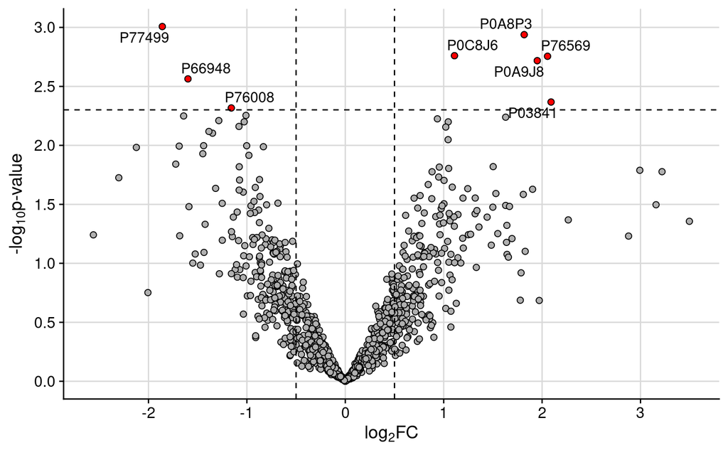

Figure 1: Volcano plot for Control versus Ampicillin

```r
volcano_plot(data = dplyr::filter(data_de_limma, group == "Ampicillin"))
```

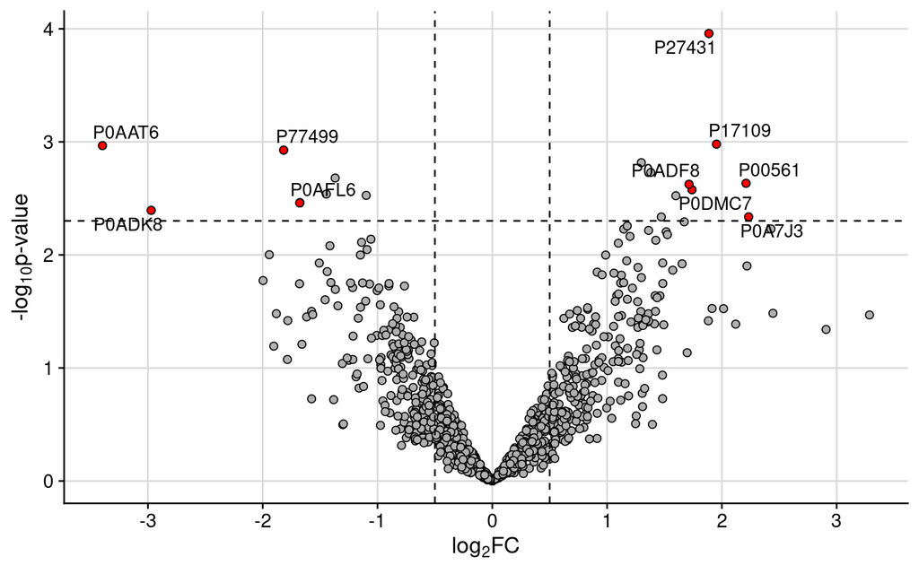

Figure 2: Volcano plot for Control versus Cefotaxime

```r
volcano_plot(data = dplyr::filter(data_de_limma, group == "Cefotaxime"))
```

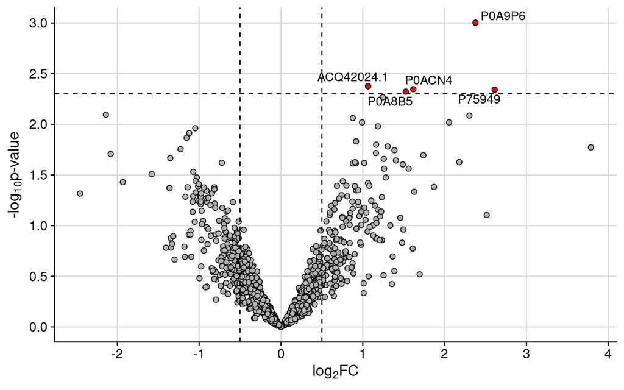

Figure 3: Volcano plot for Control versus Impipenem

```r
volcano_plot(data = dplyr::filter(data_de_limma, group == "Impipenem"))
```

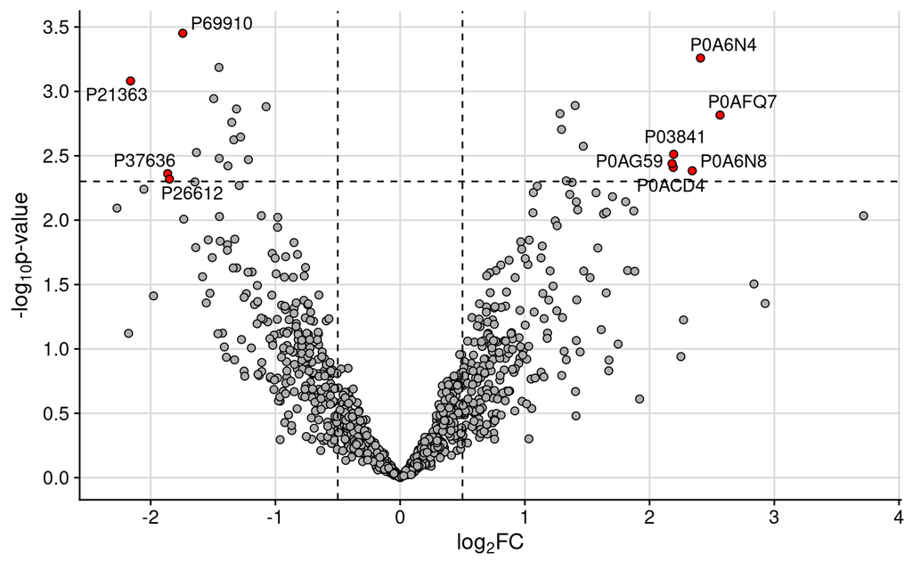

Figure 4: Volcano plot for Control versus Ciprofloxacin

```r
volcano_plot(data = dplyr::filter(data_de_limma, group == "Ciprofloxacin"))
```

# 3 Comparing the differences

```r
data_de_pivotted |>
  dplyr::group_by(group) |>
  dplyr::summarise(
    "Diff. log-FC" = paste0(round(100 * mean(diff_log_fc < 0), 3), "%"),
    "Diff. p-value" = paste0(round(100 * mean(diff_p_value < 0), 3), "%")) |>
  kableExtra::kbl() |>
  kableExtra::kable_styling(bootstrap_options = "striped", full_width = FALSE)
```

Table 1: Percentage of times that the difference in \log_2 fold-change and p-values between the methods are lesser than zero.

| group | Diff. log-FC | Diff. p-value |
| --- | --- | --- |
| Ampicillin | 53.524% | 54.626% |
| Cefotaxime | 49.559% | 61.233% |
| Ciprofloxacin | 44.163% | 61.674% |
| Impipenem | 54.956% | 55.837% |

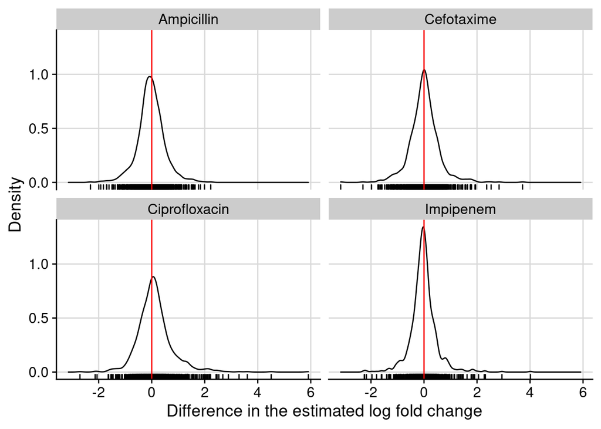

Figure 5: Distributionof the difference in the estimated $\log_2$ fold change.

```r
ggplot(data_de_pivotted, aes(x = diff_log_fc)) +
  facet_wrap(~group) +
  geom_density() +
  geom_rug() +
  geom_vline(xintercept = 0, col = "red") +
  labs(x = "Difference in the estimated log fold change", y = "Density") +
  scale_x_continuous(breaks = scales::pretty_breaks(6)) +
  scale_y_continuous(breaks = scales::pretty_breaks(4))
```

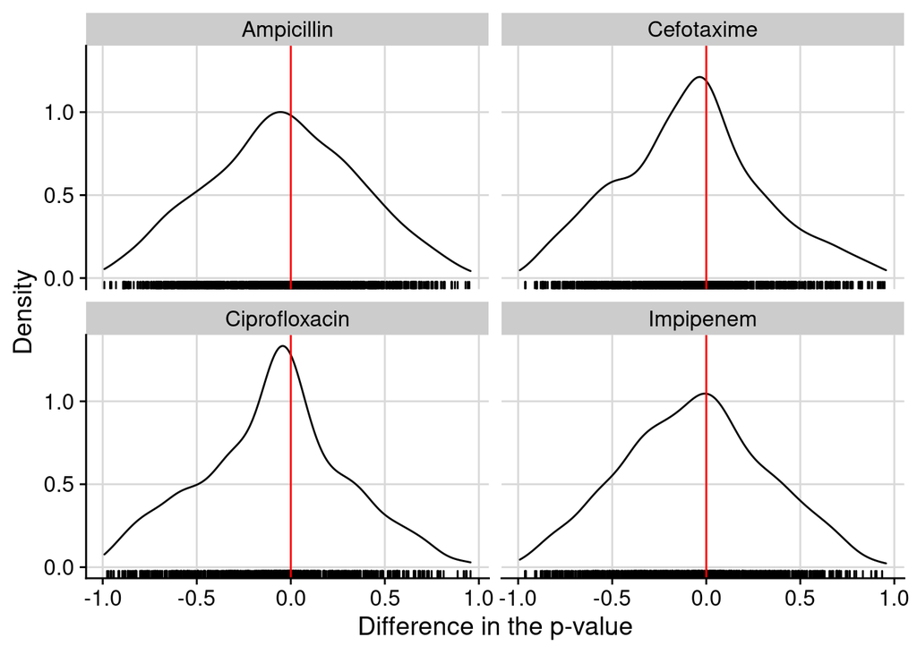

Figure 6: Distribution of the difference in the estimated p-value.

```r
ggplot(data_de_pivotted, aes(x = diff_p_value)) +
  facet_wrap(~group) +
  geom_density() +
  geom_rug() +
  geom_vline(xintercept = 0, col = "red") +
  labs(x = "Difference in the p-value", y = "Density") +
  scale_x_continuous(breaks = scales::pretty_breaks(6)) +
  scale_y_continuous(breaks = scales::pretty_breaks(4))
```

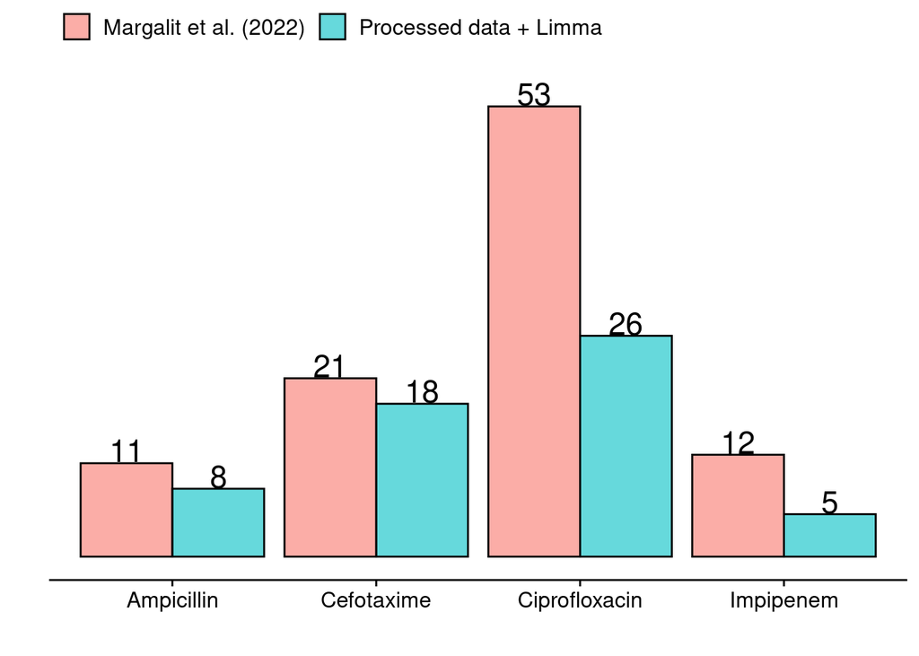

Figure 7: Total of DAP according to the method and comparison.

```r
data_de |>
  dplyr::filter(p_value <= 0.005) |>
  dplyr::group_by(method_label, group) |>
  dplyr::count() |>
  ggplot(aes(x = group, y = n, fill = method_label)) +
  geom_col(position = position_dodge(width = 0.9), alpha = 0.6,
           col = "black") +
  geom_text(aes(label = n), vjust = -0.05,
            position = position_dodge(width = 0.9), size = 6) +
  labs(x = "", y = "", fill = "") +
  scale_y_continuous(limits = c(0, 55)) +
  theme(axis.line.y = element_blank(), axis.ticks.y = element_blank(),
        panel.grid = element_blank(),
        axis.text.y = element_blank())
```

# 4 The top 3 most DA proteins

## 4.1 Comparing

```r
groups <- unique(colData(fts)$group)
groups <- groups[which(groups != "Control")]
list_de <- list()
j <- 1L
for (g in groups) {
  cat("### ", g, "\n")

  most_de_fiona <- data_de_fiona |>
    dplyr::filter(group == g, abs(log_fc) > 0.5) |>
    dplyr::arrange(p_value) |>
    head(3)

  most_de_limma <- data_de_limma |>
    dplyr::filter(group == g, abs(log_fc) > 0.5) |>
    dplyr::arrange(p_value) |>
    head(3)

  data_curr <- data_de |>
    dplyr::filter(group == g, protein %in% most_de_fiona$protein) |>
    dplyr::mutate(most_de = "fiona") |>
    dplyr::bind_rows(
      data_de |>
        dplyr::filter(group == g, protein %in% most_de_limma$protein) |>
        dplyr::mutate(most_de = "ours"))

  data_curr_f <- data_curr |>
    dplyr::filter(most_de == "fiona")
  data_curr_o <- data_curr |>
    dplyr::filter(most_de == "ours")

  # Limits
  y_lim_f <- c(min(data_curr_f$log_fc) - 0.25, max(data_curr_f$log_fc) + 0.25)
  y_lim_o <- c(min(data_curr_o$log_fc) - 0.25, max(data_curr_o$log_fc) + 0.25)

  # Plotting
  p_most_de_fiona <- ggplot(data_curr_f, aes(x = protein, y = log_fc,
                                             fill = method_label)) +
    geom_col(position = position_dodge(width = 0.9),
             alpha = 0.6, col = "black") +
    geom_hline(yintercept = 0, col = "black", size = 1.5) +
    geom_text(aes(label = paste0(round(log_fc, 2), " (",
                                 formatC(p_value, format = "e", digits = 1),
                                 ")")),
              position = position_dodge(width = 0.9), vjust = -0.2,
              size = 4) +
    labs(x = "Protein", y = "Log Fold Change", fill = "") +
    scale_y_continuous(breaks = scales::pretty_breaks(6), limits = y_lim_f) +
    ggtitle("3 most DE proteins by Margalit et al. (2022)")

  p_most_de_ours <- ggplot(data_curr_o, aes(x = protein, y = log_fc,
                                            fill = method_label)) +
    geom_col(position = position_dodge(width = 0.9),
             alpha = 0.6, col = "black") +
    geom_hline(yintercept = 0, col = "black", size = 1.5) +
    geom_text(aes(label = paste0(round(log_fc, 2), " (",
                                 formatC(p_value, format = "e", digits = 1),
                                 ")")),
              position = position_dodge(width = 0.9), vjust = -0.2,
              size = 4) +
    labs(x = "Protein", y = "Log Fold Change", fill = "") +
    scale_y_continuous(breaks = scales::pretty_breaks(6), limits = y_lim_o) +
    ggtitle("3 most DE proteins by Processed data + Limma")
  p_grided <- plot_grid(p_most_de_fiona, p_most_de_ours)

  print(p_grided)

  # Appending most DE proteins
  list_de[[j]] <- data.frame(
    group = g, fiona = most_de_fiona$protein, ours = most_de_limma$protein)
  j <- j + 1L

}
```

### 4.1.1 Ampicillin

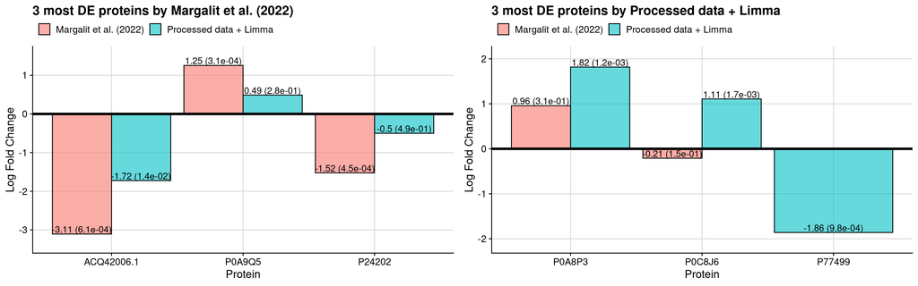

### 4.1.2 Cefotaxime

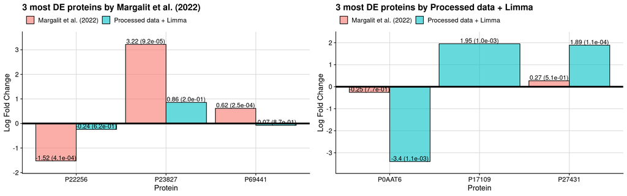

### 4.1.3 Ciprofloxacin

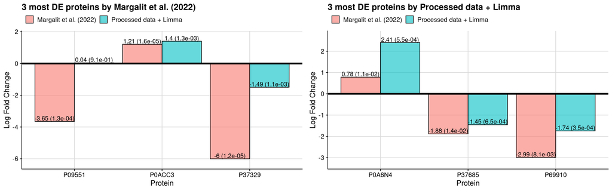

### 4.1.4 Impipenem

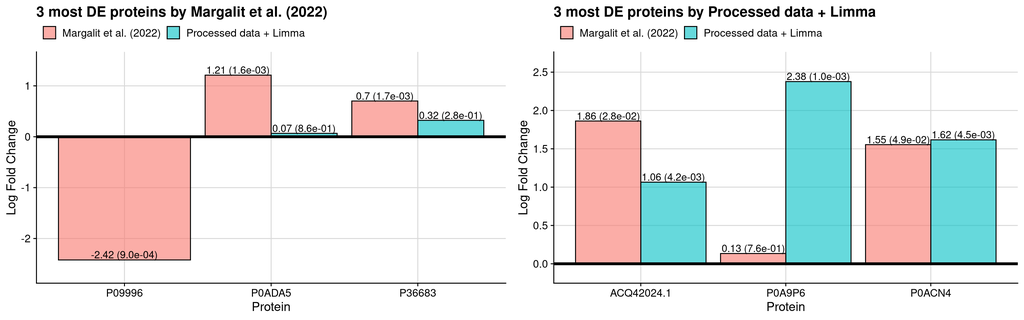

```r
de_proteins <- do.call(rbind, list_de)
```

## 4.2 The intensity distribution

```r
col_data <- dplyr::as_tibble(colData(fts)) |>
  dplyr::mutate(colname = rownames(colData(fts)))

# Function to pivot the raw intensity matrix into a long-format tibble
pivot_qfeatures <- function(fts, chosen_proteins) {
  list_tbs <- lapply(seq_len(length(fts)), function(j) {
    level <- names(fts)[j]
    se_curr <- fts[[j]]
    chosen_rows <- rowData(se_curr)$protein %in% chosen_proteins

    i_assay <- if (level == "proteins") "intensity" else 1L
    row_data_curr <- dplyr::as_tibble(
      rowData(se_curr)[chosen_rows, "protein", drop = FALSE])

    pivotted <- assay(se_curr[chosen_rows, ], i_assay) |>
      dplyr::as_tibble() |>
      dplyr::bind_cols(row_data_curr) |>
      tidyr::pivot_longer(cols = -c("protein"), names_to = "colname") |>
      dplyr::mutate(level = level)
    pivotted
  })
  do.call(rbind, list_tbs)
}

for (g in groups) {

  cat("### ", g, "\n")
  # Selecting the corresponding columns
  chosen_cols <- colData(fts)$group %in% c("Control", g)
  fts_curr <- fts[, chosen_cols]

  # Selecting the proteins
  most_de_limma <- de_proteins[de_proteins$group == g, "ours"]

  # Get the intensity values pivoted in a long format for all levels
  pivotted_limma <- pivot_qfeatures(fts = fts_curr,
                                    chosen_proteins = most_de_limma)

  # Join to get the columns data information
  pivotted_limma <- pivotted_limma |>
    dplyr::left_join(col_data, by = "colname") |>
    dplyr::select(level, protein, colname, group, replicate, sample_names,
                  value) |>
    dplyr::mutate(level = forcats::fct_relevel(
      factor(level), "psms", "peptides", "proteins"),
      group = forcats::fct_relevel(group, g)) |>
    dplyr::filter(level != "psms")

  # Plotting
  p_limma <- ggplot(pivotted_limma, aes(x = group, y = log2(value),
                                        colour = group)) +
    ggbeeswarm::geom_quasirandom(size = 2) +
    # geom_point(size = 2.5) +
    facet_wrap(protein ~ level, scales = "free", ncol = 2) +
    labs(x = "Group", y = "Log2 intensity", col = "") +
    ggtitle("Distribution of the 3 most DAP by Processed data + Limma")
  print(p_limma)

}
```

### 4.2.1 Ampicillin

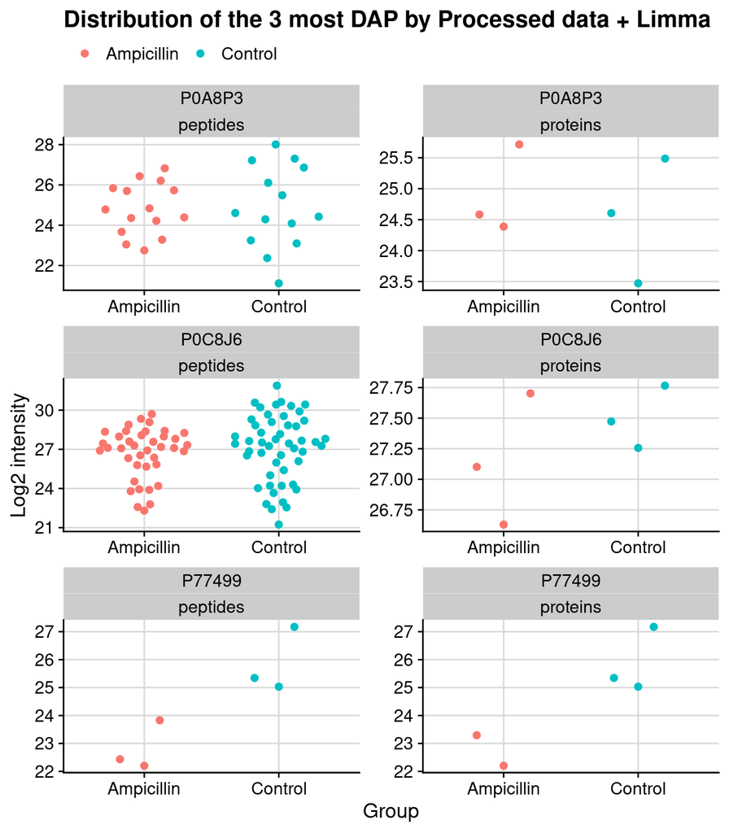

### 4.2.2 Cefotaxime

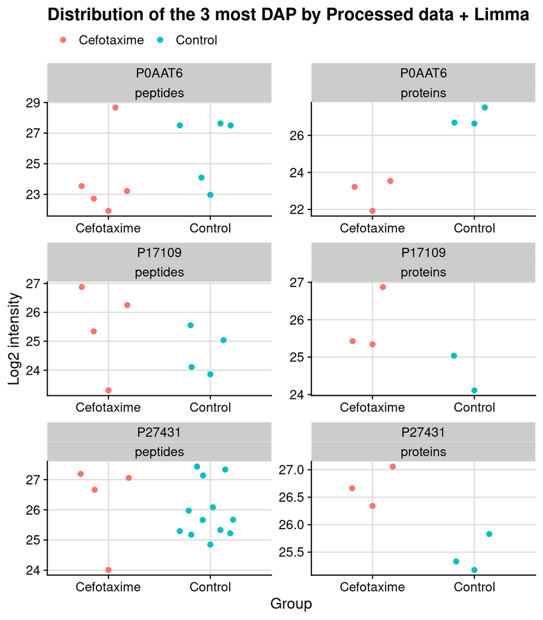

### 4.2.3 Ciprofloxacin

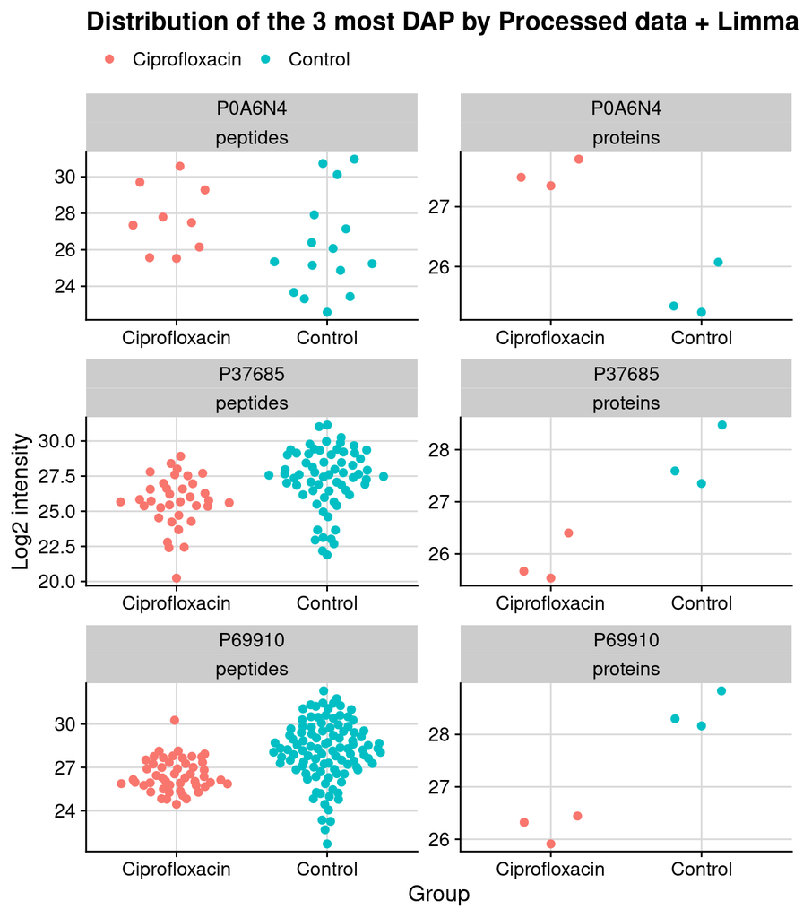

### 4.2.4 Impipenem

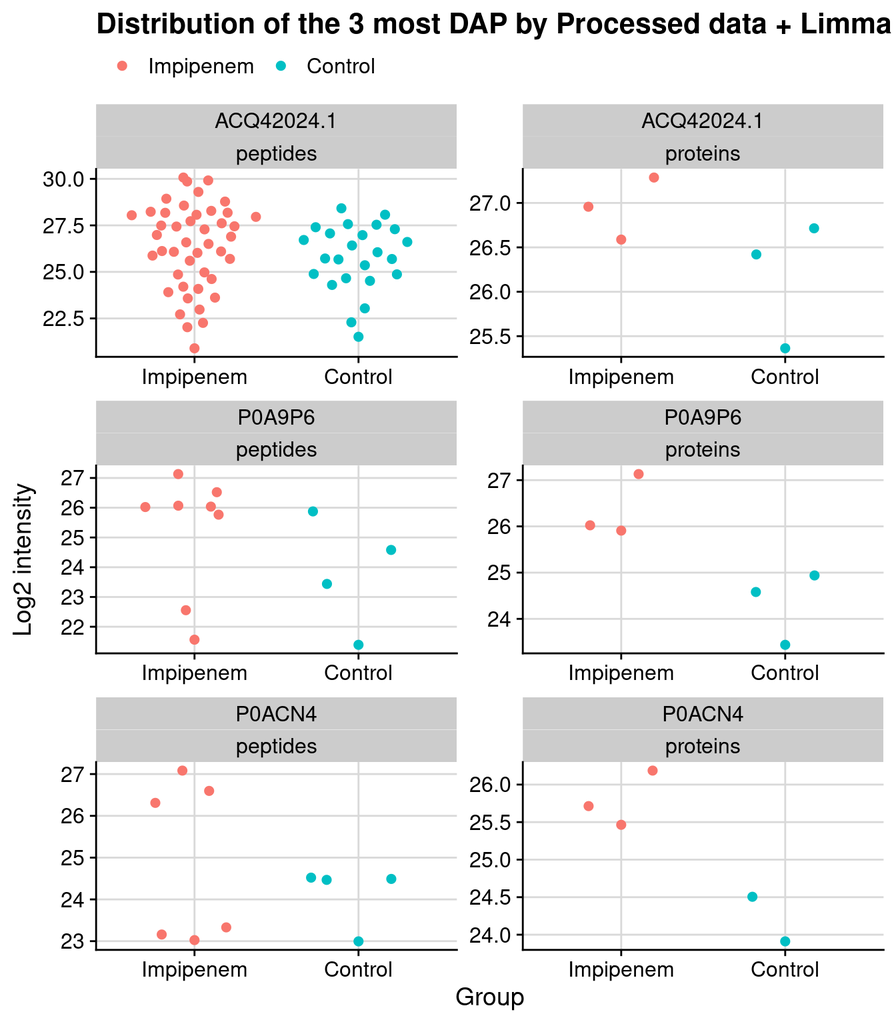

## References

Margalit, Anatte, James C. Carolan, and Fiona Walsh. 2022. “Global Protein Responses of Multidrug Resistance Plasmid-Containing Escherichia Coli to Ampicillin, Cefotaxime, Imipenem and Ciprofloxacin.” *Journal of Global Antimicrobial Resistance* 28: 90–96. https://doi.org/https://doi.org/10.1016/j.jgar.2021.12.006.

Smyth, Gordon K. 2004. “Linear Models and Empirical Bayes Methods for Assessing Differential Expression in Microarray Experiments.” *Statistical Applications in Genetics and Molecular Biology* 3 (1). https://doi.org/10.2202/1544-6115.1027.